# Dyr og væv

Measurement, precision, accuracy

Gavin Simpson

gavin@anivet.au.dk

Aarhus University

2024-09-11

## Observation

Science is fundamentally about observation

We reason about the processes that could have lead to the observations we saw

Often “observation” means taking measurements and comparing measurements from different

- subjects (individuals)
- conditions
- experimental treatments
- …

## Statistics

Statistics is one of the main tools scientists use to make sense of observations

- test specific hypothesis,
- make estimates from our sample of data,
- compare estimates under different conditions,
- summarise data

We use statistics because our observations are

- uncertain — noisy
- incomplete — we often can’t observe the whole population

## Sources of error

As scientists or someone using the tools of science we must be aware of the sources of error (uncertainty) and variation in our observations

With the fish heart measurements:

- variation among individual fish (age, sex, health, …)
- variation due to different individuals collecting the hearts
- variation due to the measurement device (balance)
- variation due to experimental conditions
- variation due to 🤷‍♂️

We use randomisation to try to handle 🤷‍♂️

## Replication

Because we see many sources of variation in the measurements we observe we replicate

- technical replicates — measure the same fish heart multiple times
- replicates — make multiple independent observations

Independent (loosely) means they provide new information

We take measurements from more than one (1) fish heart

- sex
- age
- species
- observer
- experimental treatment

## Minimise sources of variation

To the extent possible we want to minimise the

- number of sources of variation, and
- magnitude of the variation of those sources

Eliminate unneccessary sources of variation

Use a protocol and stick to it

Be as careful and consistent

## Precision vs Accuracy

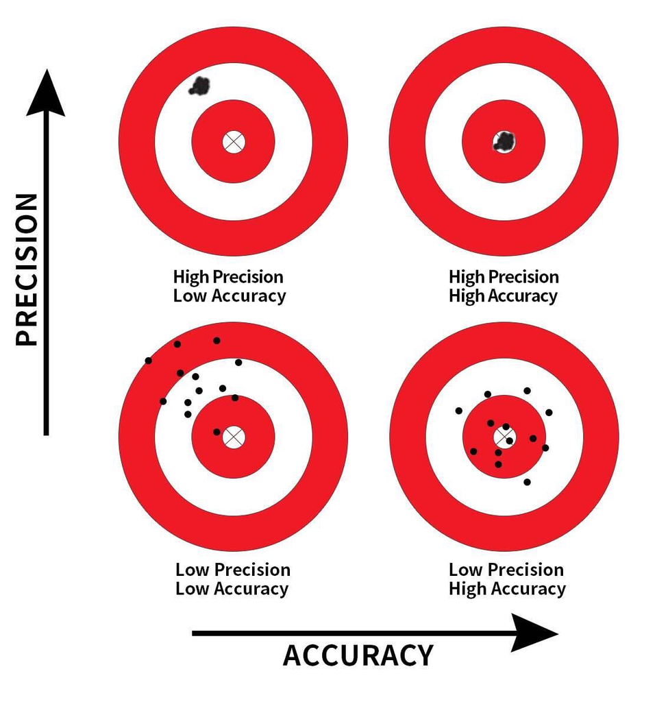

[figure not shown]

Source: Ismay & Kim (2024) [Modern Dive](https://moderndive.com/index.html) CC-BY-NC-SA

Source: [xkcd](https://imgs.xkcd.com/comics/precision_vs_accuracy.png) CC-BY-NC

## Summaries

One of the fundamental estimates we make using statistics is of the typical value — what is the weight of the typical fish heart?

We can’t possibly sample all possible fish of relevance so we will estimate the value of this typical weight

One of the most important **estimators** is the arithmetic mean — AKA the average

$$\overline{\text{weight}} = \frac{\sum_{i=1}^n \text{weight}_i}{n}$$

We add up the individual weights for each of the $n$ fish hearts; $i$ indicates which fish heart we are adding; $n$ is the number of fish hearts in out sample

## Accuracy

Statisticians refer to accuracy of estimators using the term bias

An accurate estimator is an unbiased estimator

> bias is the difference between an estimator’s expected value and the true value of the parameter being estimated

## Precision I

We can measure the variation in our data using the sample variance or standard deviation

###### Variance

$$s^2 = \widehat{\sigma}^2 = \frac{1}{n-1} \sum_{i = 1}^n \left( \text{weight}_i - \overline{\text{weight}} \right)$$

###### Standard deviation

$$s = \widehat{\sigma} = \sqrt{\frac{1}{n-1} \sum_{i = 1}^n \left( \text{weight}_i - \overline{\text{weight}} \right)}$$

Both measure the spread of the data around the typical value (the mean)

## Precision II

We can also assess the precision of our estimates

For the mean we can compute its standard error

The standard error of the mean weight of a fish heart is

$$\widehat{\sigma}_{\overline{\text{weight}}} = \frac{\widehat{\sigma}}{\sqrt{n}}$$

where $\widehat{\sigma}_{\overline{\text{weight}}}$ is the standard error of the mean fish heart; $\widehat{\sigma}$ is the standard deviation of our sample of data; $n$ is the number of indpendent observations

## Fin

The points covered in these slides are things to be thinking about while

- taking your measurements, and
- investigating the data

[figure not shown]

Gavin Simpson | Department of Animal & Veterinary Sciences